# Task14

#### (c) Try some other plausible models by experimenting with the orders chosen

```r
fit.1.3<-arima(mcopper1, order=c(1,1,0))
AIC(fit.1.3)
```

```
## [1] -75.65902
```

```r
fit.2.3<-arima(mcopper1, order=c(0,1,2))
AIC(fit.2.3)
```

```
## [1] -84.10503
```

```r
fit.3.3<-arima(mcopper1, order=c(2,1,0))
AIC(fit.3.3)
```

```
## [1] -82.55479
```

#### (d) Choose what you think is the best model and check the residual diagnostics

We are choosing model $fit.auto.3$, because it’s AIC is the lowest. We have to check if residuals look like white noise.

```r
mean(fit.res.3)
```

```
## [1] 0.01254827
```

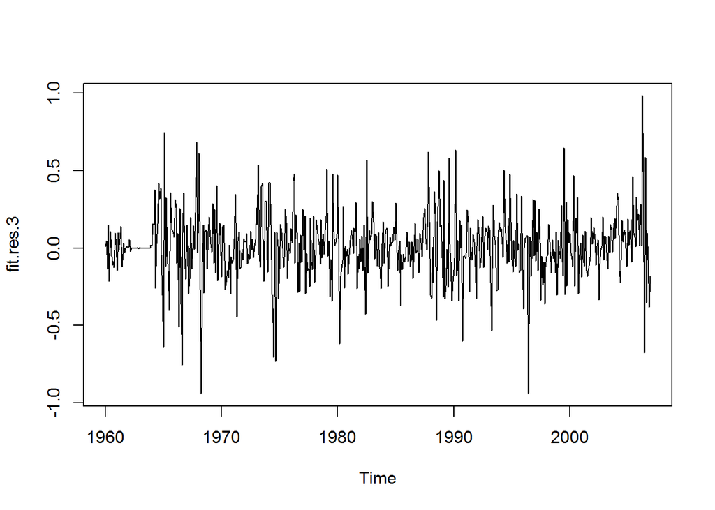

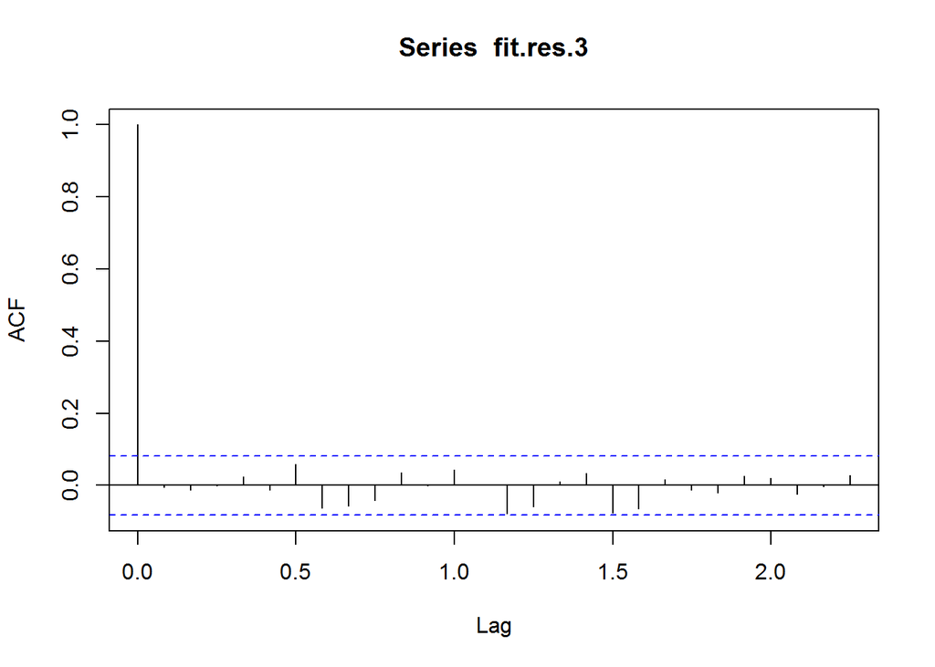

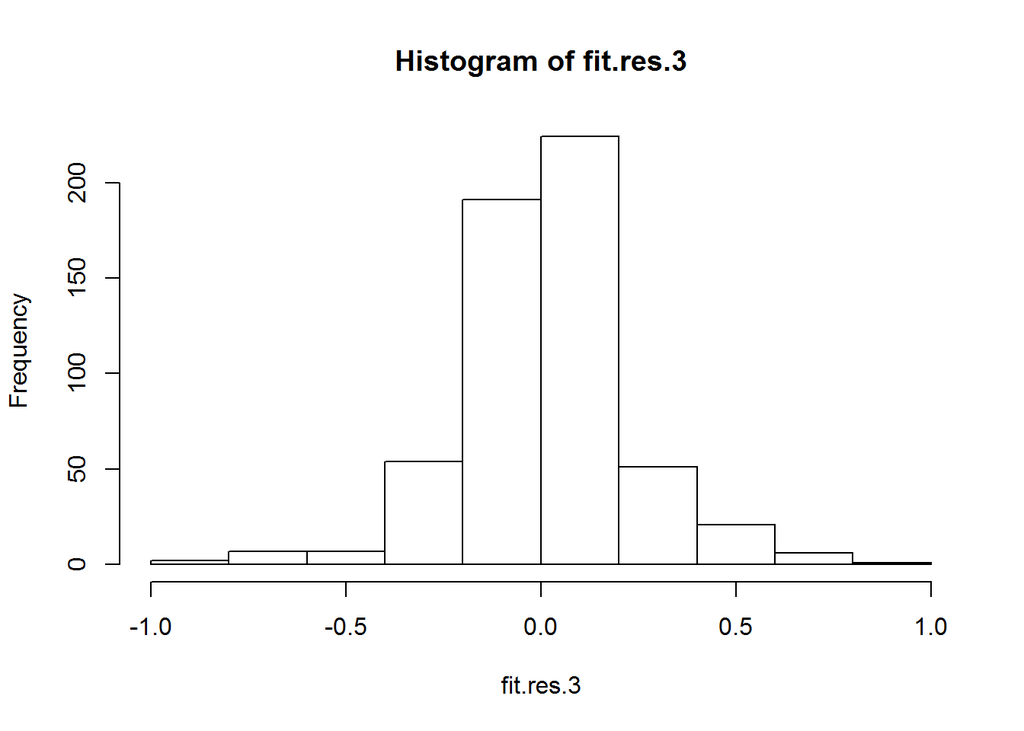

Residuals look like they are white noise - their mean is close to zero and their ACF graph shows that there is no autocorrelation.

```r
adf.test(fit.res.3)
```

```
##
##  Augmented Dickey-Fuller Test
##
## data:  fit.res.3
## Dickey-Fuller = -8.5743, Lag order = 8, p-value = 0.01
## alternative hypothesis: stationary
```

Model’s residuals are actually a white noise, $adf.test$ gives p-value lower than 0.05, which means that we have to accept alternative hypothesis, which states that series is stationary.

#### (e) Produce forecasts of your fitted model. Do the forecasts look reasonable?

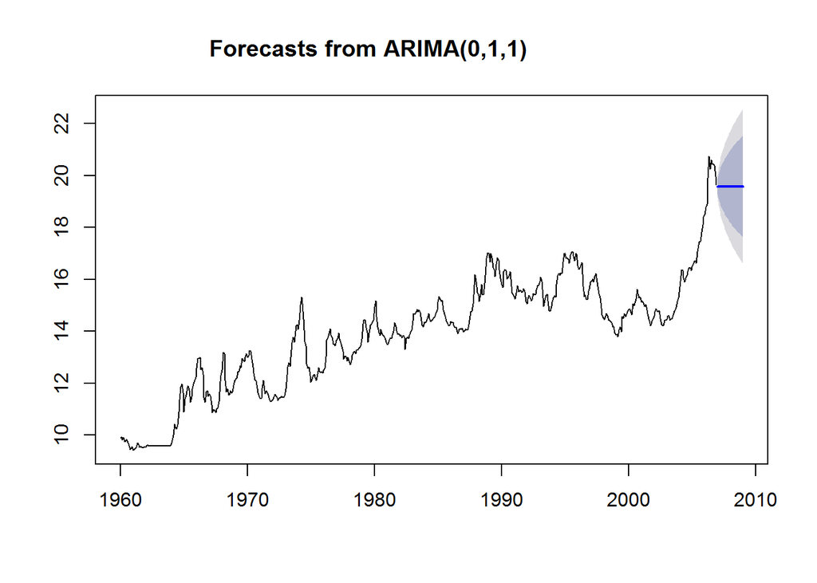

```r
plot(forecast(fit.auto.3, h=25))
```

#### (f) Compare the results with what you would obtain using ets()(with no transformation).

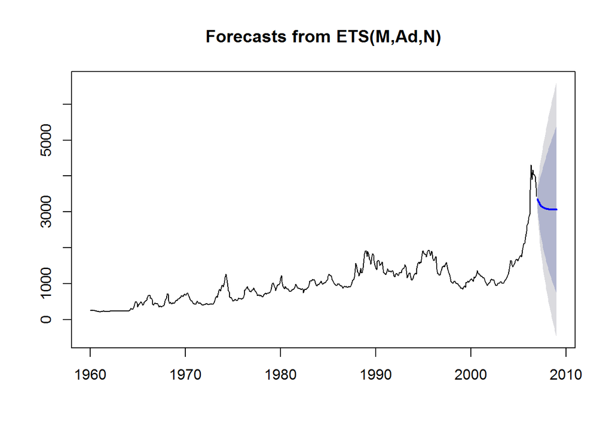

```r
accuracy(fit.auto.3)
```

```
##                      ME      RMSE       MAE        MPE     MAPE      MASE
## Training set 0.01254827 0.2231365 0.1592271 0.08049384 1.140225 0.1997301
##                      ACF1
## Training set -0.004184621
```

```r
accuracy(fit.4.3)
```

```
##                    ME     RMSE      MAE       MPE     MAPE      MASE
## Training set 2.663937 78.87828 46.74887 0.1870949 4.502486 0.2103332
##                   ACF1
## Training set 0.1030061
```

Forecast of $fit.auto.3$ gives smaller errors, so it is better than forecast using ETS.

### Conclusion

#### Auto ARIMA function does not always give the best forecasts. However, forecasting using ARIMA seems to be more accurate than forecasting with ETS, because for all of the time series that were tested, ARIMA forecasts were more accurate.